# ECON6027_1c

Dr. Liu

2024-08-22

## Create a simple data.frame

```r
fav = read.csv("1c_data.csv")
class(fav)
```

```
## [1] "data.frame"
```

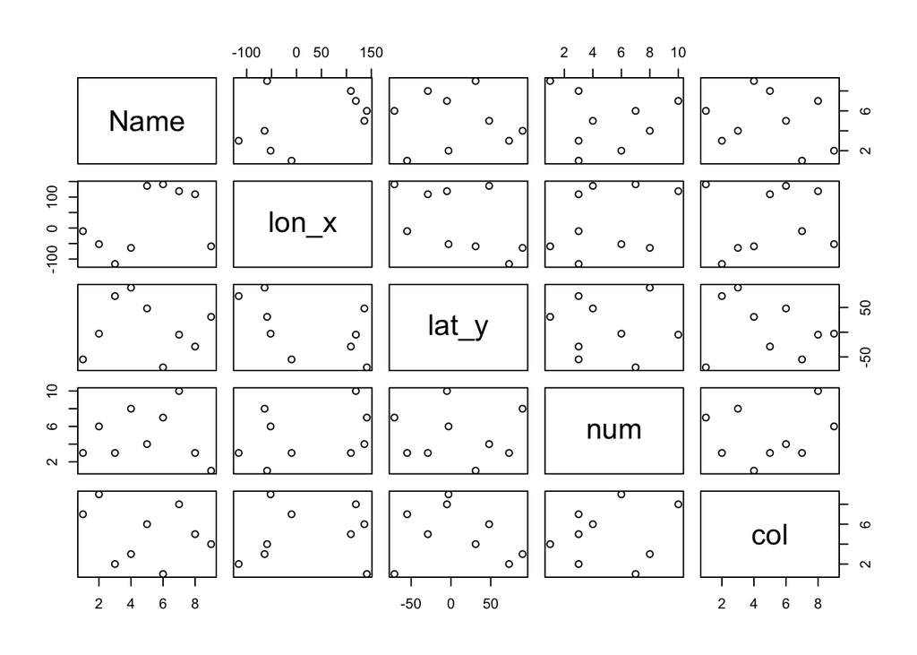

```r
plot(fav)
```

We have a spatial dataset, but this dataset has no “spatial awareness”. Let’s give it some spatial powers!

The data.frame will now be converted to a sf object using the sf package by identifying the coordinates as follows.

```r
library(sf)
(fav.sf = st_as_sf(fav, coords=c("lon_x","lat_y")))
```

```
## Simple feature collection with 9 features and 3 fields
## Geometry type: POINT
## Dimension:     XY
## Bounding box:  xmin: -116 ymin: -71 xmax: 141 ymax: 90
## CRS:           NA
##   Name num    col        geometry
## 1  ABC   3    red POINT (-10 -55)
## 2  DEF   6 yellow  POINT (-52 -3)
## 3  GHI   3   blue POINT (-116 73)
## 4  JKL   8  green  POINT (-64 90)
## 5  MNO   4 purple  POINT (136 48)
## 6  PQR   7  black POINT (141 -71)
## 7  STU  10  white  POINT (119 -5)
## 8   VW   3   pink POINT (109 -29)
## 9  XYZ   1 orange  POINT (-59 31)
```

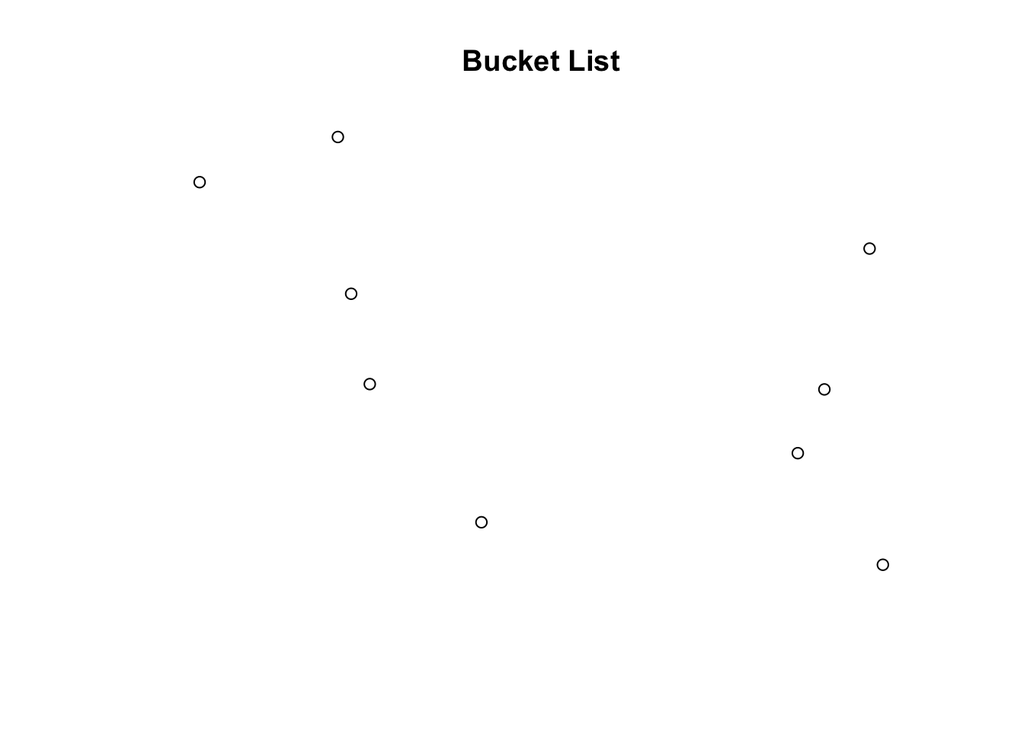

```r
plot(st_geometry(fav.sf), main="Bucket List")
```

The “coords” argument follows the cartesian coordinates convention (x,y). Notice the lack of CRS: R knows these are locations but not quite sure where…

## Roll up your sleeves

Load the “world” dataset from spData. Install this package if you have not done so already. spData is a diverse spatial datasets for demonstrating, benchmarking and teaching spatial data analysis.

We will load and inspect the “world” dataset.

```r
world = st_read(system.file("shapes/world.gpkg", package="spData"))
world
```

```
## Simple feature collection with 177 features and 10 fields
## Geometry type: MULTIPOLYGON
## Dimension:     XY
## Bounding box:  xmin: -180 ymin: -89.9 xmax: 180 ymax: 83.64513
## Geodetic CRS:  WGS 84
## First 10 features:
##    iso_a2        name_long     continent region_un          subregion
## 1      FJ             Fiji       Oceania   Oceania          Melanesia
## 2      TZ         Tanzania        Africa    Africa     Eastern Africa
## 3      EH   Western Sahara        Africa    Africa    Northern Africa
## 4      CA           Canada North America  Americas   Northern America
## 5      US    United States North America  Americas   Northern America
## 6      KZ       Kazakhstan          Asia      Asia       Central Asia
## 7      UZ       Uzbekistan          Asia      Asia       Central Asia
## 8      PG Papua New Guinea       Oceania   Oceania          Melanesia
```

[output cut: 24 more lines]

Now, let us inspect the dataset.

```r
table(st_is_valid(world))
```

```
##
## TRUE
##  177
```

```r
class(world)
```

```
## [1] "sf"         "data.frame"
```

```r
dim(world) # 177 features, 11 attributes
```

```
## [1] 177  11
```

```r
names(world)
```

```
##  [1] "iso_a2"    "name_long" "continent" "region_un" "subregion" "type"
##  [7] "area_km2"  "pop"       "lifeExp"   "gdpPercap" "geom"
```

```r
summary(world)
```

```
##     iso_a2           name_long          continent          region_un
##  Length:177         Length:177         Length:177         Length:177
##  Class :character   Class :character   Class :character   Class :character
##  Mode  :character   Mode  :character   Mode  :character   Mode  :character
##
##
##
##
##   subregion             type              area_km2             pop
##  Length:177         Length:177         Min.   :    2417   Min.   :5.630e+04
##  Class :character   Class :character   1st Qu.:   46185   1st Qu.:3.755e+06
##  Mode  :character   Mode  :character   Median :  185004   Median :1.040e+07
##                                        Mean   :  832558   Mean   :4.282e+07
##                                        3rd Qu.:  621860   3rd Qu.:3.075e+07
##                                        Max.   :17018507   Max.   :1.364e+09
##                                                           NA's   :10
##     lifeExp        gdpPercap                   geom
##  Min.   :50.62   Min.   :   597.1   MULTIPOLYGON :177
##  1st Qu.:64.96   1st Qu.:  3752.4   epsg:4326    :  0
##  Median :72.87   Median : 10734.1   +proj=long...:  0
##  Mean   :70.85   Mean   : 17106.0
##  3rd Qu.:76.78   3rd Qu.: 24232.7
##  Max.   :83.59   Max.   :120860.1
##  NA's   :10      NA's   :17
```

```r
head(world)
```

```
## Simple feature collection with 6 features and 10 fields
## Geometry type: MULTIPOLYGON
## Dimension:     XY
## Bounding box:  xmin: -180 ymin: -18.28799 xmax: 180 ymax: 83.23324
## Geodetic CRS:  WGS 84
##   iso_a2      name_long     continent region_un        subregion
## 1     FJ           Fiji       Oceania   Oceania        Melanesia
## 2     TZ       Tanzania        Africa    Africa   Eastern Africa
## 3     EH Western Sahara        Africa    Africa  Northern Africa
## 4     CA         Canada North America  Americas Northern America
## 5     US  United States North America  Americas Northern America
## 6     KZ     Kazakhstan          Asia      Asia     Central Asia
##                type    area_km2       pop  lifeExp gdpPercap
## 1 Sovereign country    19289.97    885806 69.96000  8222.254
## 2 Sovereign country   932745.79  52234869 64.16300  2402.099
## 3     Indeterminate    96270.60        NA       NA        NA
## 4 Sovereign country 10036042.98  35535348 81.95305 43079.143
## 5           Country  9510743.74 318622525 78.84146 51921.985
## 6 Sovereign country  2729810.51  17288285 71.62000 23587.338
##                             geom
## 1 MULTIPOLYGON (((-180 -16.55...
## 2 MULTIPOLYGON (((33.90371 -0...
## 3 MULTIPOLYGON (((-8.66559 27...
## 4 MULTIPOLYGON (((-132.71 54....
## 5 MULTIPOLYGON (((-171.7317 6...
## 6 MULTIPOLYGON (((87.35997 49...
```

Geometry column of the dataset contains the coordinate data. If you remove the geometry column, the sf object reverts to a simple data.frame.

```r
world$geom
```

```
## Geometry set for 177 features
## Geometry type: MULTIPOLYGON
## Dimension:     XY
## Bounding box:  xmin: -180 ymin: -89.9 xmax: 180 ymax: 83.64513
## Geodetic CRS:  WGS 84
## First 5 geometries:
```

```
## MULTIPOLYGON (((-180 -16.55522, -179.9174 -16.5...
```

```
## MULTIPOLYGON (((33.90371 -0.95, 31.86617 -1.027...
```

```
## MULTIPOLYGON (((-8.66559 27.65643, -8.817828 27...
```

```
## MULTIPOLYGON (((-132.71 54.04001, -133.18 54.16...
```

```
## MULTIPOLYGON (((-171.7317 63.78252, -171.7911 6...
```

```r
world_df = st_drop_geometry(world)
class(world_df)
```

```
## [1] "data.frame"
```

```r
head(world_df)
```

```
##   iso_a2      name_long     continent region_un        subregion
## 1     FJ           Fiji       Oceania   Oceania        Melanesia
## 2     TZ       Tanzania        Africa    Africa   Eastern Africa
## 3     EH Western Sahara        Africa    Africa  Northern Africa
## 4     CA         Canada North America  Americas Northern America
## 5     US  United States North America  Americas Northern America
## 6     KZ     Kazakhstan          Asia      Asia     Central Asia
##                type    area_km2       pop  lifeExp gdpPercap
## 1 Sovereign country    19289.97    885806 69.96000  8222.254
## 2 Sovereign country   932745.79  52234869 64.16300  2402.099
## 3     Indeterminate    96270.60        NA       NA        NA
## 4 Sovereign country 10036042.98  35535348 81.95305 43079.143
## 5           Country  9510743.74 318622525 78.84146 51921.985
## 6 Sovereign country  2729810.51  17288285 71.62000 23587.338
```

## Initial plots

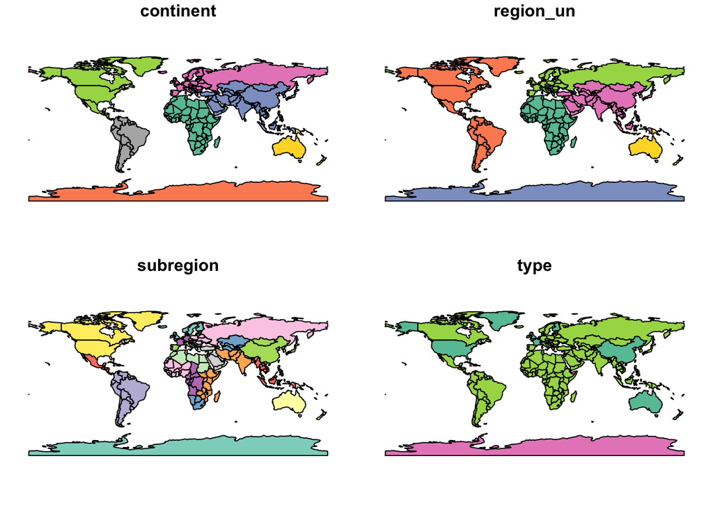

```r
# plot(world)
plot(world[3:6])
```

Basic plot of the countries and continents based on column name.

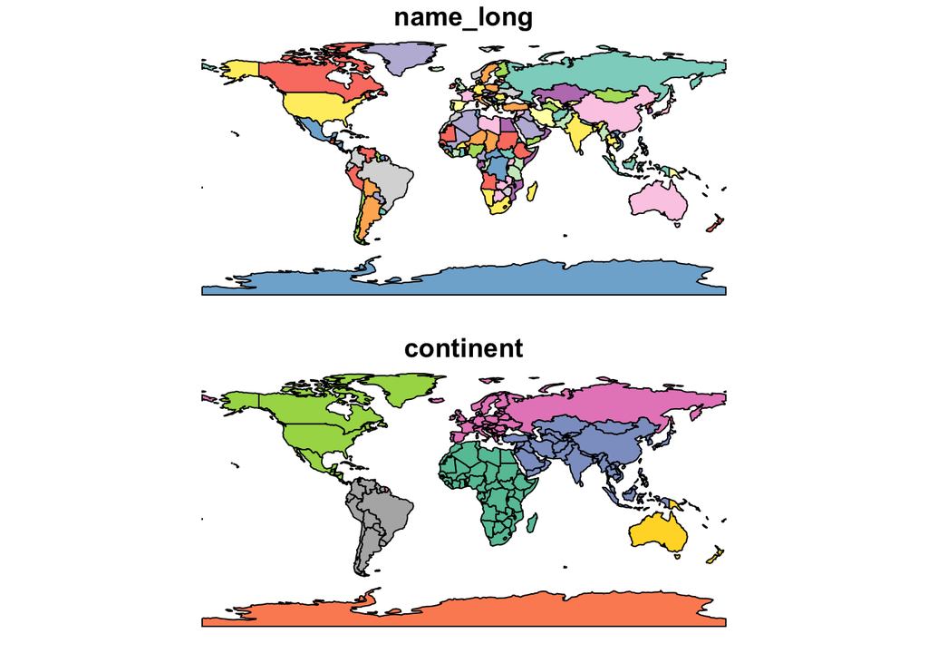

```r
plot(world[c("name_long", "continent")])
```

## Spatial dataset manipulation

In this section we will see some important ways to manipulate a spatial dataset. Most of these commands can be applied to any dataset in general.

### 1. Subsetting using base R functions [] or subset()

The following code chunk shows how to subset based on columns.

```r
world[, 7:10] # Extract columns 7 to 10
```

```
## Simple feature collection with 177 features and 4 fields
## Geometry type: MULTIPOLYGON
## Dimension:     XY
## Bounding box:  xmin: -180 ymin: -89.9 xmax: 180 ymax: 83.64513
## Geodetic CRS:  WGS 84
## First 10 features:
##       area_km2       pop  lifeExp gdpPercap                           geom
## 1     19289.97    885806 69.96000  8222.254 MULTIPOLYGON (((-180 -16.55...
## 2    932745.79  52234869 64.16300  2402.099 MULTIPOLYGON (((33.90371 -0...
## 3     96270.60        NA       NA        NA MULTIPOLYGON (((-8.66559 27...
## 4  10036042.98  35535348 81.95305 43079.143 MULTIPOLYGON (((-132.71 54....
## 5   9510743.74 318622525 78.84146 51921.985 MULTIPOLYGON (((-171.7317 6...
## 6   2729810.51  17288285 71.62000 23587.338 MULTIPOLYGON (((87.35997 49...
## 7    461410.26  30757700 71.03900  5370.866 MULTIPOLYGON (((55.96819 41...
## 8    464520.07   7755785 65.23000  3709.082 MULTIPOLYGON (((141.0002 -2...
## 9   1819251.33 255131116 68.85600 10003.089 MULTIPOLYGON (((104.37 -1.0...
## 10  2784468.59  42981515 76.25200 18797.548 MULTIPOLYGON (((-68.63401 -...
```

```r
summary(world[, 7:10]) # numerical summary of the columns
```

```
##     area_km2             pop               lifeExp        gdpPercap
##  Min.   :    2417   Min.   :5.630e+04   Min.   :50.62   Min.   :   597.1
##  1st Qu.:   46185   1st Qu.:3.755e+06   1st Qu.:64.96   1st Qu.:  3752.4
##  Median :  185004   Median :1.040e+07   Median :72.87   Median : 10734.1
##  Mean   :  832558   Mean   :4.282e+07   Mean   :70.85   Mean   : 17106.0
##  3rd Qu.:  621860   3rd Qu.:3.075e+07   3rd Qu.:76.78   3rd Qu.: 24232.7
##  Max.   :17018507   Max.   :1.364e+09   Max.   :83.59   Max.   :120860.1
##                     NA's   :10          NA's   :10      NA's   :17
##             geom
##  MULTIPOLYGON :177
##  epsg:4326    :  0
##  +proj=long...:  0
##
##
##
##
```

The following code chunk allows subsetting based on certain criterion: lad area more than 5 million square km.

Method 1

```r
l_area = world$area_km2 > 5000000
class(l_area)
```

```
## [1] "logical"
```

```r
table(l_area)
```

```
## l_area
## FALSE  TRUE
##   170     7
```

```r
(big_countries = world[l_area, ])
```

```
## Simple feature collection with 7 features and 10 fields
## Geometry type: MULTIPOLYGON
## Dimension:     XY
## Bounding box:  xmin: -180 ymin: -89.9 xmax: 180 ymax: 83.23324
## Geodetic CRS:  WGS 84
##     iso_a2          name_long     continent  region_un
## 4       CA             Canada North America   Americas
## 5       US      United States North America   Americas
## 19      RU Russian Federation        Europe     Europe
## 30      BR             Brazil South America   Americas
## 138     AU          Australia       Oceania    Oceania
## 140     CN              China          Asia       Asia
## 160     AQ         Antarctica    Antarctica Antarctica
##                     subregion              type area_km2        pop  lifeExp
## 4            Northern America Sovereign country 10036043   35535348 81.95305
## 5            Northern America           Country  9510744  318622525 78.84146
## 19             Eastern Europe Sovereign country 17018507  143819666 70.74366
## 30              South America Sovereign country  8508557  204213133 75.04200
## 138 Australia and New Zealand           Country  7687614   23504138 82.30000
## 140              Eastern Asia           Country  9409830 1364270000 75.93200
## 160                Antarctica     Indeterminate 12335956         NA       NA
##     gdpPercap                           geom
## 4    43079.14 MULTIPOLYGON (((-132.71 54....
## 5    51921.98 MULTIPOLYGON (((-171.7317 6...
## 19   25284.59 MULTIPOLYGON (((180 70.8322...
## 30   15374.26 MULTIPOLYGON (((-53.37366 -...
## 138  43547.20 MULTIPOLYGON (((126.1487 -3...
## 140  12758.65 MULTIPOLYGON (((80.25999 42...
## 160        NA MULTIPOLYGON (((-180 -89.9,...
```

Method 2

```r
(big_countries = subset(world, area_km2 > 5000000)) # method 2
```

```
## Simple feature collection with 7 features and 10 fields
## Geometry type: MULTIPOLYGON
## Dimension:     XY
## Bounding box:  xmin: -180 ymin: -89.9 xmax: 180 ymax: 83.23324
## Geodetic CRS:  WGS 84
##     iso_a2          name_long     continent  region_un
## 4       CA             Canada North America   Americas
## 5       US      United States North America   Americas
## 19      RU Russian Federation        Europe     Europe
## 30      BR             Brazil South America   Americas
## 138     AU          Australia       Oceania    Oceania
## 140     CN              China          Asia       Asia
## 160     AQ         Antarctica    Antarctica Antarctica
##                     subregion              type area_km2        pop  lifeExp
## 4            Northern America Sovereign country 10036043   35535348 81.95305
## 5            Northern America           Country  9510744  318622525 78.84146
## 19             Eastern Europe Sovereign country 17018507  143819666 70.74366
## 30              South America Sovereign country  8508557  204213133 75.04200
## 138 Australia and New Zealand           Country  7687614   23504138 82.30000
## 140              Eastern Asia           Country  9409830 1364270000 75.93200
## 160                Antarctica     Indeterminate 12335956         NA       NA
##     gdpPercap                           geom
## 4    43079.14 MULTIPOLYGON (((-132.71 54....
## 5    51921.98 MULTIPOLYGON (((-171.7317 6...
## 19   25284.59 MULTIPOLYGON (((180 70.8322...
## 30   15374.26 MULTIPOLYGON (((-53.37366 -...
## 138  43547.20 MULTIPOLYGON (((126.1487 -3...
## 140  12758.65 MULTIPOLYGON (((80.25999 42...
## 160        NA MULTIPOLYGON (((-180 -89.9,...
```

Since Antartica is not a country, we will remove it from the dataset.

```r
(big_countries = big_countries[-7, ]) # remove Antarctica
```

```
## Simple feature collection with 6 features and 10 fields
## Geometry type: MULTIPOLYGON
## Dimension:     XY
## Bounding box:  xmin: -180 ymin: -43.6346 xmax: 180 ymax: 83.23324
## Geodetic CRS:  WGS 84
##     iso_a2          name_long     continent region_un                 subregion
## 4       CA             Canada North America  Americas          Northern America
## 5       US      United States North America  Americas          Northern America
## 19      RU Russian Federation        Europe    Europe            Eastern Europe
## 30      BR             Brazil South America  Americas             South America
## 138     AU          Australia       Oceania   Oceania Australia and New Zealand
## 140     CN              China          Asia      Asia              Eastern Asia
##                  type area_km2        pop  lifeExp gdpPercap
## 4   Sovereign country 10036043   35535348 81.95305  43079.14
## 5             Country  9510744  318622525 78.84146  51921.98
## 19  Sovereign country 17018507  143819666 70.74366  25284.59
## 30  Sovereign country  8508557  204213133 75.04200  15374.26
## 138           Country  7687614   23504138 82.30000  43547.20
## 140           Country  9409830 1364270000 75.93200  12758.65
##                               geom
## 4   MULTIPOLYGON (((-132.71 54....
## 5   MULTIPOLYGON (((-171.7317 6...
## 19  MULTIPOLYGON (((180 70.8322...
## 30  MULTIPOLYGON (((-53.37366 -...
## 138 MULTIPOLYGON (((126.1487 -3...
## 140 MULTIPOLYGON (((80.25999 42...
```

In the next chunk, we will extract and highlight Asia (a specific geographic location) in a map.

Using [] is one way to subset a dataset. Notice the resulting dataset is also an sf object.

```r
table(world$continent)
```

```
##
##                  Africa              Antarctica                    Asia
##                      51                       1                      47
##                  Europe           North America                 Oceania
##                      39                      18                       7
## Seven seas (open ocean)           South America
##                       1                      13
```

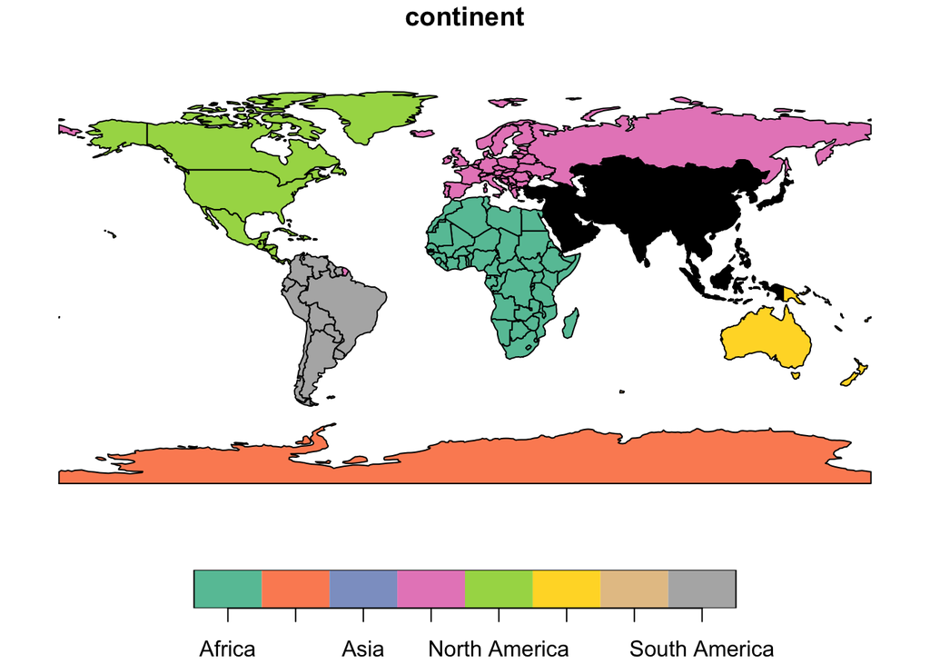

```r
asia = world[world$continent == "Asia", ]
plot(world["continent"], reset = F)
plot(asia, add = T, col = "black")
```

Plot Sri Lanka (Also a possible solution to Exercise B)

```r
world$name_long
```

```
##   [1] "Fiji"
##   [2] "Tanzania"
##   [3] "Western Sahara"
##   [4] "Canada"
##   [5] "United States"
##   [6] "Kazakhstan"
##   [7] "Uzbekistan"
##   [8] "Papua New Guinea"
##   [9] "Indonesia"
##  [10] "Argentina"
##  [11] "Chile"
##  [12] "Democratic Republic of the Congo"
##  [13] "Somalia"
##  [14] "Kenya"
##  [15] "Sudan"
```

[output cut: 162 more lines]

```r
(sl = world[world$name_long == "Sri Lanka", ])
```

```
## Simple feature collection with 1 feature and 10 fields
## Geometry type: MULTIPOLYGON
## Dimension:     XY
## Bounding box:  xmin: 79.69517 ymin: 5.96837 xmax: 81.78796 ymax: 9.824078
## Geodetic CRS:  WGS 84
##     iso_a2 name_long continent region_un     subregion              type
## 139     LK Sri Lanka      Asia      Asia Southern Asia Sovereign country
##     area_km2      pop lifeExp gdpPercap                           geom
## 139 65370.39 20771000  74.906  10650.39 MULTIPOLYGON (((81.78796 7....
```

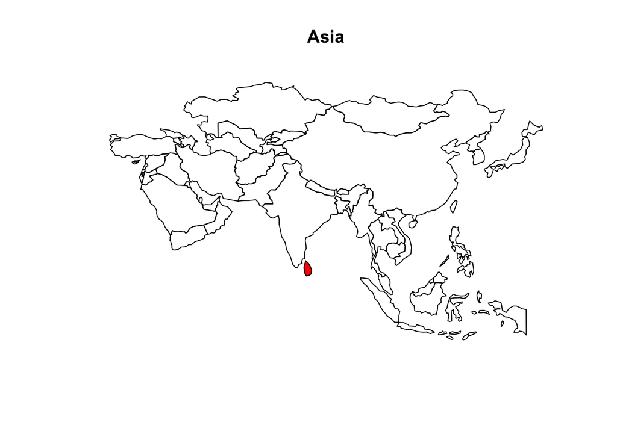

```r
plot(st_geometry(asia), main="Asia")
plot(st_geometry(sl), col = "red", add=T)
```

plot(st_geometry()) gives an outline of the geometry column.

### 2. Attribute data aggregation

Aggregation operations summarise datasets by a ‘grouping variable’, typically an attribute column. In the following example, we aggregate the population by continent.

```r
(cont_pop = aggregate(pop ~ continent, FUN = sum, data = world, na.rm = T)); class(cont_pop) # output is a data.frame
```

```
##       continent        pop
## 1        Africa 1154946633
## 2          Asia 4311408059
## 3        Europe  669036256
## 4 North America  565028684
## 5       Oceania   37757833
## 6 South America  412060811
```

```
## [1] "data.frame"
```

```r
(cont_pop2 = aggregate(world['pop'], by = list(world$continent), FUN = sum, na.rm = T)); class(cont_pop2) # results in an sf output
```

```
## Simple feature collection with 8 features and 2 fields
## Attribute-geometry relationships: aggregate (1), identity (1)
## Geometry type: GEOMETRY
## Dimension:     XY
## Bounding box:  xmin: -180 ymin: -89.9 xmax: 180 ymax: 83.64513
## Geodetic CRS:  WGS 84
##                   Group.1        pop                       geometry
## 1                  Africa 1154946633 MULTIPOLYGON (((-11.43878 6...
## 2              Antarctica          0 MULTIPOLYGON (((-61.13898 -...
## 3                    Asia 4311408059 MULTIPOLYGON (((48.67923 14...
## 4                  Europe  669036256 MULTIPOLYGON (((-53.55484 2...
## 5           North America  565028684 MULTIPOLYGON (((-155.2222 1...
## 6                 Oceania   37757833 MULTIPOLYGON (((147.9141 -4...
## 7 Seven seas (open ocean)          0 POLYGON ((68.935 -48.625, 6...
## 8           South America  412060811 MULTIPOLYGON (((-68.63999 -...
```

```
## [1] "sf"         "data.frame"
```

```r
# (cont_pop2 = aggregate(world$pop, by = list(world$continent), FUN = sum, na.rm = T)); class(cont_pop2)
```

### 3. Attribute joining using “key variable”

Idea is to join data from different sources. This is useful when you want to “give” spatial awareness to a dataset. In the following example, we will use the “coffee_data” dataset from spData and join that to the “world” dataset using the key variable “name_long”

```r
library(spData)
summary(coffee_data)
```

```
##   name_long         coffee_production_2016 coffee_production_2017
##  Length:47          Min.   :   1.0         Min.   :   1.00
##  Class :character   1st Qu.:   3.0         1st Qu.:   3.75
##  Mode  :character   Median :  36.5         Median :  40.00
##                     Mean   : 261.3         Mean   : 250.53
##                     3rd Qu.: 140.2         3rd Qu.: 178.75
##                     Max.   :3277.0         Max.   :2786.00
##                     NA's   :9              NA's   :11
```

```r
class(coffee_data)
```

```
## [1] "tbl_df"     "tbl"        "data.frame"
```

```r
library(dplyr)
# left join
(world_coffee = left_join(world, coffee_data))
```

```
## Simple feature collection with 177 features and 12 fields
## Geometry type: MULTIPOLYGON
## Dimension:     XY
## Bounding box:  xmin: -180 ymin: -89.9 xmax: 180 ymax: 83.64513
## Geodetic CRS:  WGS 84
## First 10 features:
##    iso_a2        name_long     continent region_un          subregion
## 1      FJ             Fiji       Oceania   Oceania          Melanesia
## 2      TZ         Tanzania        Africa    Africa     Eastern Africa
## 3      EH   Western Sahara        Africa    Africa    Northern Africa
## 4      CA           Canada North America  Americas   Northern America
## 5      US    United States North America  Americas   Northern America
## 6      KZ       Kazakhstan          Asia      Asia       Central Asia
## 7      UZ       Uzbekistan          Asia      Asia       Central Asia
## 8      PG Papua New Guinea       Oceania   Oceania          Melanesia
```

[output cut: 24 more lines]

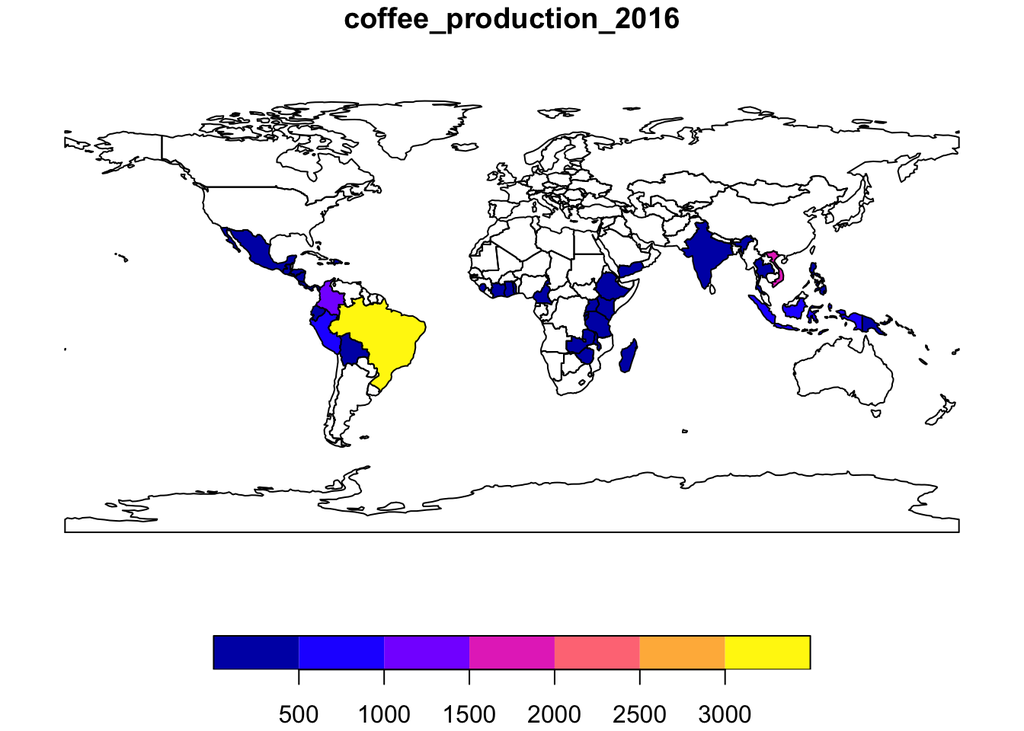

```r
plot(world_coffee["coffee_production_2016"])
```

```r
# inner join
(world_coffee2 = inner_join(world, coffee_data))
```

```
## Simple feature collection with 45 features and 12 fields
## Geometry type: MULTIPOLYGON
## Dimension:     XY
## Bounding box:  xmin: -117.1278 ymin: -33.76838 xmax: 156.02 ymax: 35.49401
## Geodetic CRS:  WGS 84
## First 10 features:
##    iso_a2          name_long     continent region_un          subregion
## 1      TZ           Tanzania        Africa    Africa     Eastern Africa
## 2      PG   Papua New Guinea       Oceania   Oceania          Melanesia
## 3      ID          Indonesia          Asia      Asia South-Eastern Asia
## 4      KE              Kenya        Africa    Africa     Eastern Africa
## 5      DO Dominican Republic North America  Americas          Caribbean
## 6      TL        Timor-Leste          Asia      Asia South-Eastern Asia
## 7      MX             Mexico North America  Americas    Central America
## 8      BR             Brazil South America  Americas      South America
```

[output cut: 24 more lines]

Notice the joining is done using the shared “key” variable “name_long”. By default,dplyr uses all variables with matching names. In this case, both world_coffee and world objects contained a variable called name_long, explaining the message Joining, by = “name_long”. Where variable names are not the same, you have two options: (1) Rename the key variable in one of the objects so they match, or (2) Use the by argument to specify the joining variables.

The difference between the two functions is that left_join() fully preserves the features of the left dataset while inner_join() will find the common elements belonging to both datasets. You may choose the desired function based on the final dataset you need.

### 4. Create new attributes

```r
world_coffee$prod_yoy = (world_coffee$coffee_production_2017/world_coffee$coffee_production_2016 - 1)*100
world_coffee
```

```
## Simple feature collection with 177 features and 13 fields
## Geometry type: MULTIPOLYGON
## Dimension:     XY
## Bounding box:  xmin: -180 ymin: -89.9 xmax: 180 ymax: 83.64513
## Geodetic CRS:  WGS 84
## First 10 features:
##    iso_a2        name_long     continent region_un          subregion
## 1      FJ             Fiji       Oceania   Oceania          Melanesia
## 2      TZ         Tanzania        Africa    Africa     Eastern Africa
## 3      EH   Western Sahara        Africa    Africa    Northern Africa
## 4      CA           Canada North America  Americas   Northern America
## 5      US    United States North America  Americas   Northern America
## 6      KZ       Kazakhstan          Asia      Asia       Central Asia
## 7      UZ       Uzbekistan          Asia      Asia       Central Asia
## 8      PG Papua New Guinea       Oceania   Oceania          Melanesia
```

[output cut: 35 more lines]